# Check the Potrs gene overlap with Potra gene

Nicolas Delhomme

2015-04-23

# 1 Setup

Set the working dir

```r
setwd("/mnt/picea/projects/aspseq/asp201/rna/gmap/Potra01")
```

Load libraries

```r
suppressPackageStartupMessages(library(digest))
suppressPackageStartupMessages(library(genomeIntervals))
suppressPackageStartupMessages(library(GenomicRanges))
suppressPackageStartupMessages(library(igraph))
suppressPackageStartupMessages(library(LSD))
suppressPackageStartupMessages(library(RColorBrewer))
```

Create a palette

```r
pal <- brewer.pal(8,"Dark2")
```

Source and helper function

```r
source("~/Git/UPSCb/src/R/plot.multidensity.R")
```

# 2 Perform the assessment

Reading in the gene gff3

```r
Potrs.gff3 <- readGff3("Potra01-Potrs-all-genes.gff3")
Potra.gff3 <- readGff3("Potra01-gene-only.gff3")
```

Reading in the intersect data

```r
dat <- read.delim("Potrs01_Potra01-gene_intersect.tsv",stringsAsFactors=FALSE,header=FALSE)
```

Report on the number of overlaps

```r
sprintf("There are %s feature overlaps",nrow(dat))
```

```
## [1] "There are 41468 feature overlaps"
```

```r
sprintf("Originating from %s Potrs genes overlapping %s Potra genes",
        length(unique(sub(".*Name=","",dat[,9]))),
        length(unique(dat[,18])))
```

```
## [1] "Originating from 35062 Potrs genes overlapping 26056 Potra genes"
```

We might have haplotypes assembled in Potrs

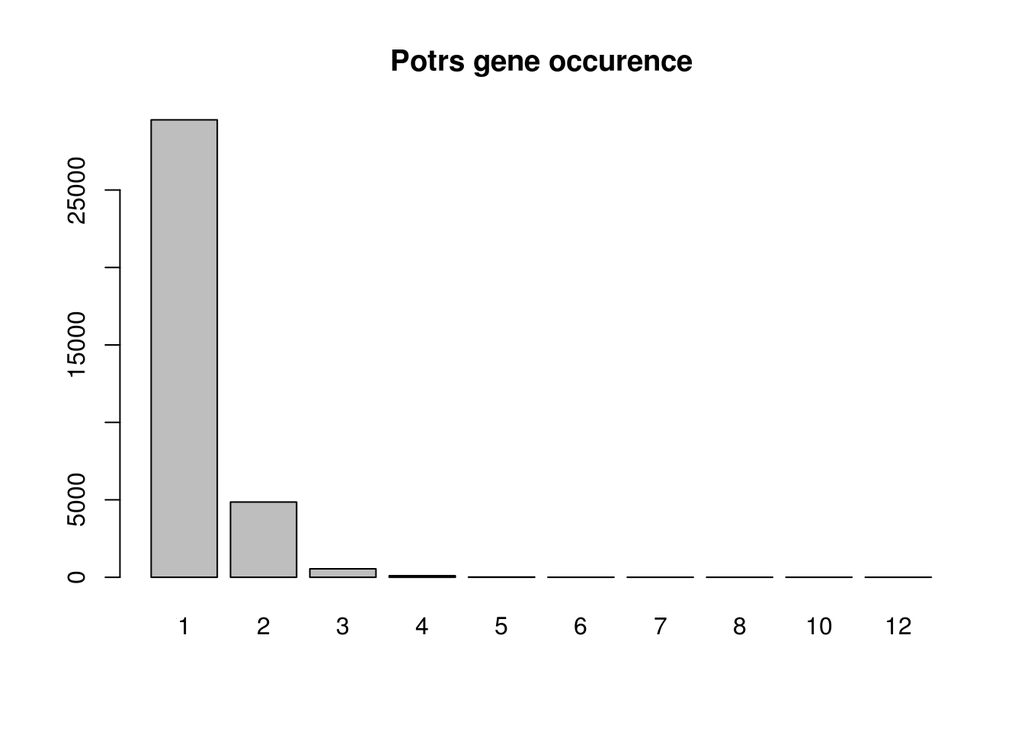

```r
barplot(table(table(sub(".*Name=","",dat[,9]))),main="Potrs gene occurence")
```

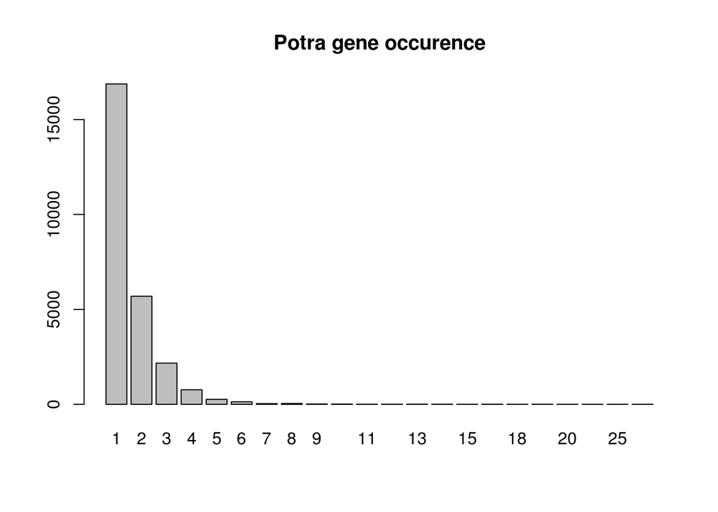

```r
barplot(table(table(dat[,18])),main="Potra gene occurence")
```

Report on the number of missed genes

```r
sprintf("There are %s Potrs genes not overlapping a Potra gene",
length(Potrs.gff3$gffAttributes[!Potrs.gff3$gffAttributes %in% unique(dat[,9])]))
```

```
## [1] "There are 1767 Potrs genes not overlapping a Potra gene"
```

```r
sprintf("And there are %s Potra genes not overlapped by a Potrs gene",
        length(Potra.gff3$gffAttributes[!Potra.gff3$gffAttributes %in% unique(dat[,18])]))
```

```
## [1] "And there are 7552 Potra genes not overlapped by a Potrs gene"
```

Next, we look at the overlap sizes, calculating the query and subject length

```r
dat$query.length <- dat[,19] / (dat[,5] - dat[,4] + 1)
dat$subject.length <- dat[,19] / (dat[,14] - dat[,13] + 1)
```

Most of the Potrs are fully contained

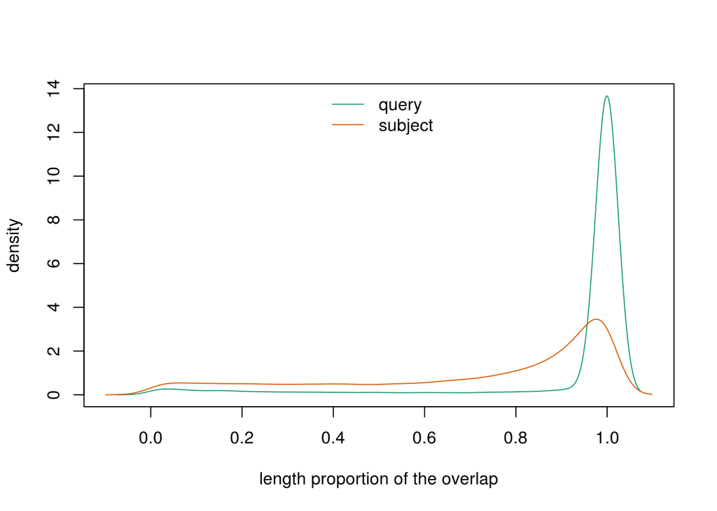

```r
plot.multidensity(list(query=dat$query.length,
                       subject=dat$subject.length),
                  xlab="length proportion of the overlap")
```

Most Potrs are fully contained and fully represent the Potra A large proportion of Potrs are partial representation of the Potra A smaller proportion of Potra are contained in longer Potrs A cluster of Potra and Potrs only overlap by about 20%

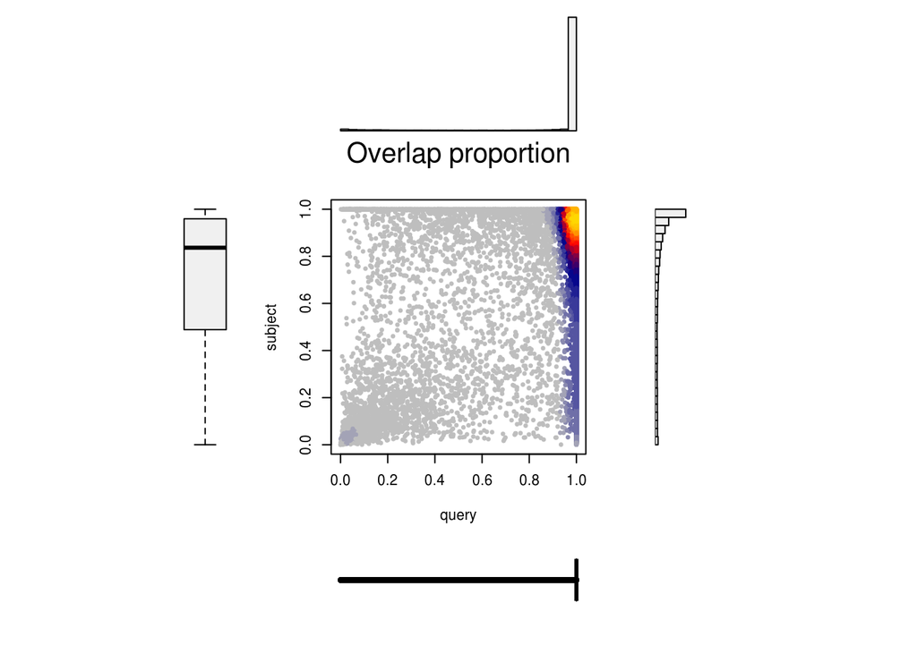

```r
comparisonplot(dat$query.length,
               dat$subject.length,
               main="Overlap proportion",
                 xlab="query",
                 ylab="subject")
```

Is this size related?

It is for the query where the shorter are more fully covered.

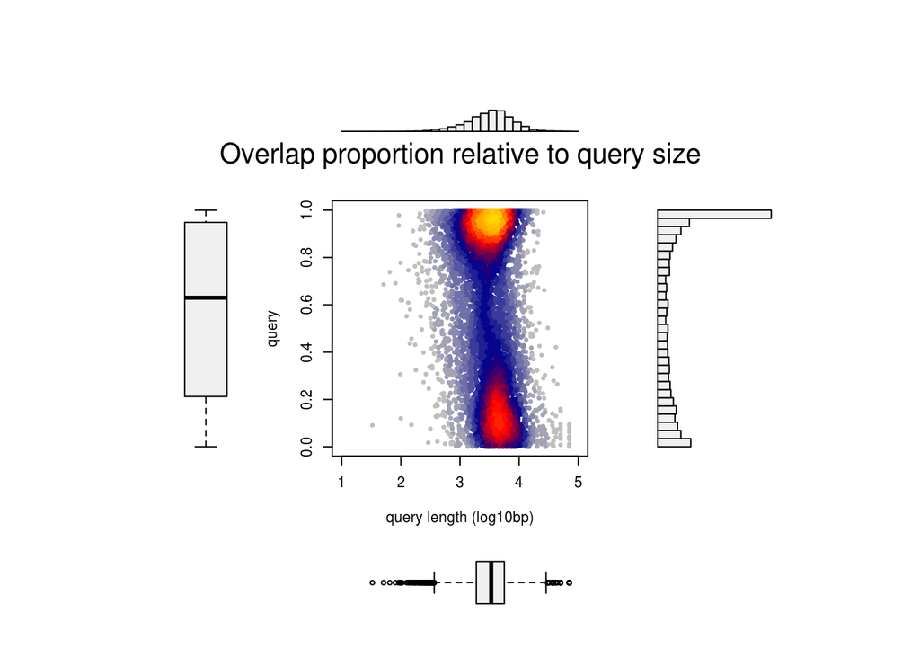

```r
comparisonplot(log10(dat[,5] - dat[,4] + 1),
               dat$query.length,
               main="Overlap proportion relative to query size",
               ylab="query",xlim=c(1,5),
               xlab="query length (log10bp)",ylim=c(0,1))
```

It is for Potra, although the separation is less clear

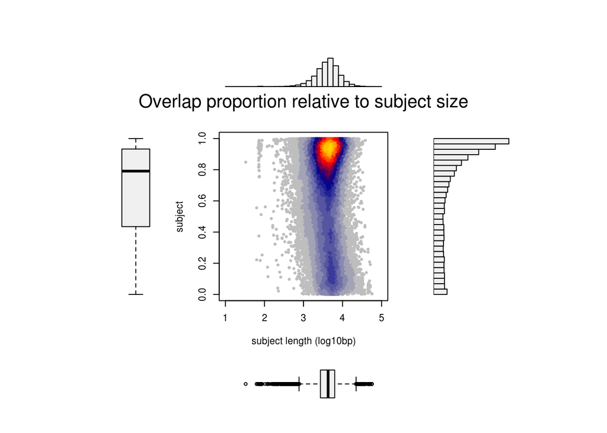

```r
comparisonplot(log10(dat[,14] - dat[,13] + 1),
               dat$subject.length,
               main="Overlap proportion relative to subject size",
               ylab="subject",xlim=c(1,5),
               xlab="subject length (log10bp)",ylim=c(0,1))
```

What about the genes located in the 20%-20% square They tend to be longer genes. It is likely that the overlap is due to them being neighbouring genes; i.e. UTR overlap

```r
sel <- dat$query.length <= 0.2 & dat$subject.length <= 0.2
sprintf("There are %s genes in that 20 percent quadrant",sum(sel))
```

```
## [1] "There are 1116 genes in that 20 percent quadrant"
```

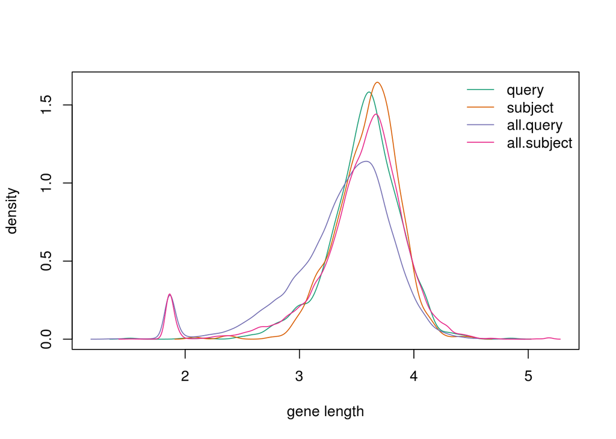

```r
plot.multidensity(list(query=log10(dat[,5] - dat[,4] + 1)[sel],
                       subject=log10(dat[,14] - dat[,13] + 1)[sel],
                       all.query=log10(dat[,5] - dat[,4] + 1),
                       all.subject=log10(dat[,14] - dat[,13] + 1)),
                  xlab="gene length",legend.x="topright")
```

Looking at the strand orientation Majority is similarly stranded (all data)

```r
table(dat[,7],dat[,16])
```

```
##
##         +     -
##   + 17082  3602
##   -  4172 16612
```

The situation is identical for the fully contained queries. Which is worrying to some extend as it might indicate that some features are wrongly annotated

```r
table(dat[dat$query.length==1,7],
      dat[dat$query.length==1,16])
```

```
##
##         +     -
##   + 14348  2353
##   -  2732 14099
```

The proportion seems constant no matter the subset. It could also be a GMAP artefact.

```r
table(dat[dat$subject.length==1,7],
      dat[dat$subject.length==1,16])
```

```
##
##        +    -
##   + 1738  284
##   -  334 1992
```

```r
table(dat[dat$query.length<0.9 & dat$subject.length==1,7],
      dat[dat$query.length<0.9 & dat$subject.length==1,16])
```

```
##
##       +   -
##   + 468 163
##   - 198 490
```

Luckily it gets inverted for the genes in the 20 percent overlap quadrant.

```r
table(dat[sel,7],dat[sel,16])
```

```
##
##       +   -
##   + 182 394
##   - 392 148
```

Check the confidence of the genes on different strands to assess whether it is an annotation issue or if it is a GMAP issue. There is no enrichment for low confidence genes, so it hopefully is a GMAP issue.

```r
table(getGffAttribute(
  Potra.gff3[Potra.gff3$gffAttributes %in% unique(dat[dat[,7] != dat[,16],18]),],
  "confidence"),useNA="always")
```

```
##
##  Low <NA>
##  374 5201
```

Let’s select genes within the 20% quadrant and those missed to subselect from the GMAP gff.

```r
gIDs <- c(getGffAttribute(Potrs.gff3[!Potrs.gff3$gffAttributes %in% unique(dat[,9])],"ID"),
getGffAttribute(Potrs.gff3[Potrs.gff3$gffAttributes %in% unique(dat[sel,9])],"ID"))

sprintf("We retrieve %s missing genes",length(gIDs))
```

```
## [1] "We retrieve 2872 missing genes"
```

# 3 Gff3 retrieval

Get the highest gene ID

```r
maxID <- max(as.integer(sub(".*g","",getGffAttribute(Potra.gff3,"ID"))))
```

Read the GMAP gff3s

```r
gff3 <- c(readGff3("Potra01-Potrs01-mRNA.gff3.mult"),
          readGff3("Potra01-Potrs01-mRNA.gff3.transloc"),
          readGff3("Potra01-Potrs01-mRNA.gff3.uniq"))
```

extract the ID and Parent

```r
IDs <- getGffAttribute(gff3,"ID")
Parent <- getGffAttribute(gff3,"Parent")
```

Traverse the gff3 hierarchy and collate all required IDs

```r
ID.sel <- IDs %in% c(gIDs,
                     IDs[Parent %in% gIDs],
                     IDs[Parent %in% IDs[Parent %in% gIDs]])

sprintf("We extract %s features from a total of %s",sum(ID.sel),length(ID.sel))
```

```
## [1] "We extract 29415 features from a total of 522262"
```

```r
gff3 <- gff3[ID.sel,]
```

## 3.1 Consistency check

Get the selected ID and Parents

```r
IDs <- getGffAttribute(gff3,"ID")[,1]
Parent <- getGffAttribute(gff3,"Parent")[,1]
```

Collapse the hierarchy

```r
l1 <- IDs[match(Parent,IDs)]
l2 <- Parent[match(l1,IDs)]
l2[is.na(l2)] <- ifelse(is.na(Parent[is.na(l2)]),IDs[is.na(l2)],Parent[is.na(l2)])
```

Check that all genes have 4 levels (gene,mRNA,exon,CDS); otherwise drop

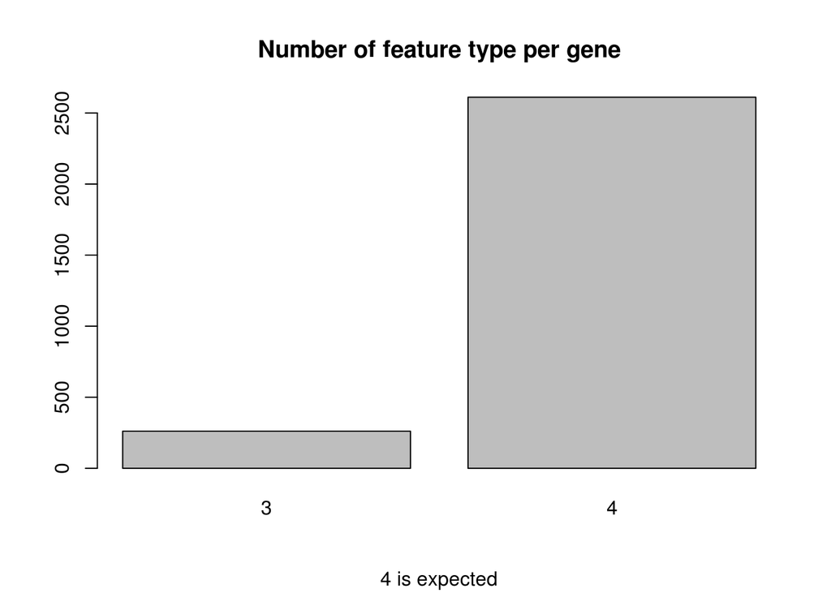

```r
all.feats <- sapply(lapply(split(as.character(gff3$type),l2),unique),length)
barplot(table(all.feats),main="Number of feature type per gene",sub="4 is expected")
```

Filter the incomplete (missing CDS) out

```r
gff3 <- gff3[!l2 %in% names(which(all.feats!=4)),]
```

See if any of the remaining overlap, i.e. if the same locus has been matched several times.

```r
grngs <- GRanges(seqnames=seq_name(gff3[gff3$type=="gene",]),
        ranges=IRanges(start=gff3[gff3$type=="gene",1],
                       end=gff3[gff3$type=="gene",2]),
        strand=strand(gff3[gff3$type=="gene",]))

ovl <- findOverlaps(grngs,ignoreSelf=TRUE,ignoreRedundant=TRUE)
```

Just check the connectivity of the overlap

```r
graf <- graph.edgelist(matrix(as.character(as.matrix(ovl)),nrow=length(ovl)))
sprintf("There are %s clusters with %s members",
        clusters(graf)$no,
        length(unique(c(queryHits(ovl),subjectHits(ovl)))))
```

```
## [1] "There are 308 clusters with 732 members"
```

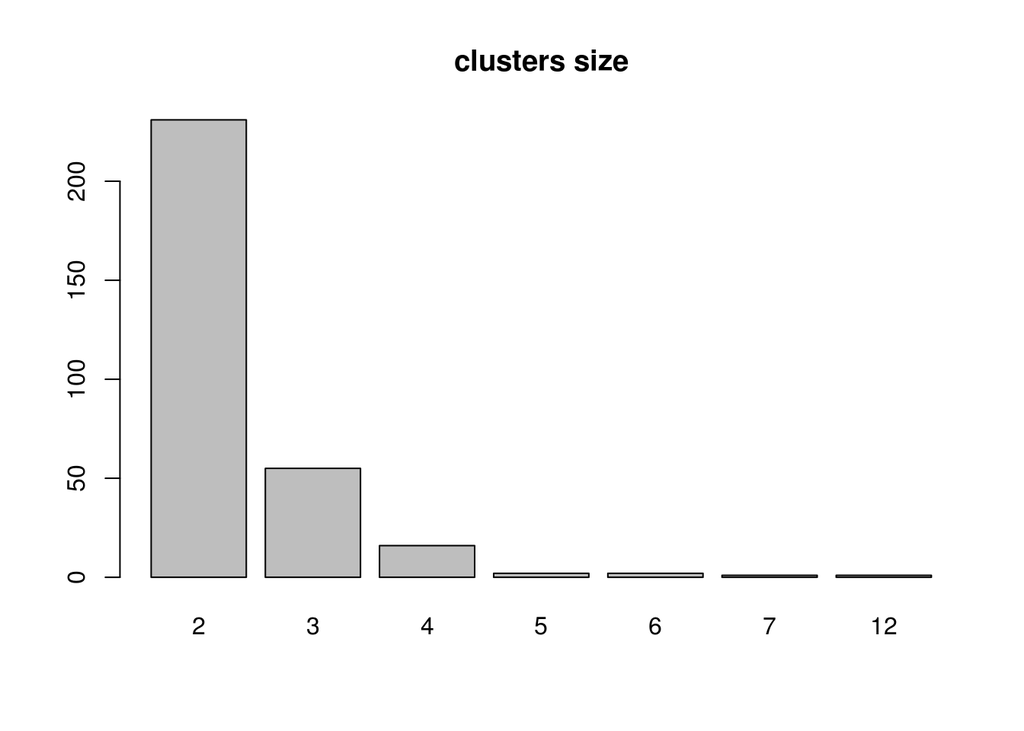

```r
barplot(table(clusters(graf)$csize),main="clusters size")
```

There are quite many loci that seem redundant. Check the percentage overlap of these. It is actually obvious that these must be in all likelihood alternative splice variants, since we used all mRNAs from Potrs.

```r
percent.ovl <- t(apply(as.matrix(ovl),1,
                     function(ro,grng){
                       g <- grng[ro]
                       (min(end(g)) - max(start(g)) + 1) / width(g)
                     },grngs))
```

Most are fully overlapping

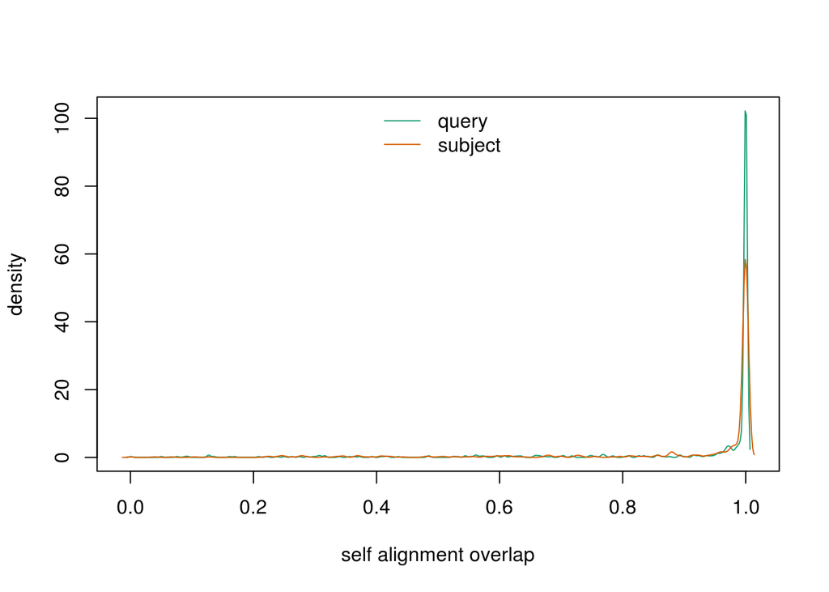

```r
plot.multidensity(list(query=percent.ovl[,1],
                       subject=percent.ovl[,2]),
                  xlab="self alignment overlap")
```

A minimal fraction represent partial overlaps only

```r
table(rowSums(percent.ovl==1))
```

```
##
##   0   1   2
##  64 304 255
```

Check what the amount is for an 80% overlap

```r
table(rowSums(percent.ovl[percent.ovl[,1] < 1 & percent.ovl[,2] < 1,] > 0.8))
```

```
##
##  0  1  2
## 12 21 31
```

A handful only does not overlap

```r
percent.ovl[percent.ovl[,1] < 1 & percent.ovl[,2] < 1,][
  rowSums(percent.ovl[percent.ovl[,1] < 1 & percent.ovl[,2] < 1,] > 0.8) == 0,]
```

```
##               [,1]         [,2]
##  [1,] 0.1282570932 0.3673300166
##  [2,] 0.2380636605 0.4065685164
##  [3,] 0.1358517980 0.6285714286
##  [4,] 0.0885585003 0.2164296998
##  [5,] 0.6285714286 0.2454068241
##  [6,] 0.5751633987 0.4097788126
##  [7,] 0.1281457911 0.3673300166
##  [8,] 0.6644144144 0.4867986799
##  [9,] 0.4854545455 0.5920177384
## [10,] 0.4839006440 0.5072324012
## [11,] 0.7188449848 0.5591016548
## [12,] 0.0007380074 0.0003238342
```

## 3.2 Flatten the redundant

For those that overlap above 80%, we need to merge the gene Keep the longest coordinate for a single gene, drop all other genes, reference that only parent and list Potrs IDs in the attribute, comma sep.

```r
graf <- graph.edgelist(matrix(
  c(getGffAttribute(gff3[gff3$type=="gene",],"ID")[queryHits(ovl)],
  getGffAttribute(gff3[gff3$type=="gene",],"ID")[subjectHits(ovl)]),
  ncol=2)[percent.ovl[,1] >= 0.8 | percent.ovl[,2] >= 0.8,])
```

Retrieve all coordinates

```r
g.start <- start(grngs)
g.end <- end(grngs)
names(g.start) <- names(g.end) <- getGffAttribute(gff3[gff3$type=="gene",],"ID")
```

Process

```r
red.gff <- do.call("c",mclapply(1:clusters(graf)$no,function(i,g,s,e,id,p,gff3){
                     message(i)
  # get the edges in the cluster
  nams <- get.vertex.attribute(g,"name")[which(clusters(g)$membership == i)]
  # get the sub gff
  gff <- gff3[id %in% c(nams,id[p %in% nams],id[p %in% id[p %in% nams]]),]

  # update the gene
  gen <- gff[gff$type=="gene",][1,]
  gen[,1] <- min(s[nams])
  gen[,2] <- max(e[nams])
  newID <- sprintf("%sg%05d",seq_name(gen),maxID + i)
  gen$gffAttributes <- sprintf("ID=%s;Name=%s;potrs=%s;confidence=Low",
                               newID,newID,
                               paste(sub("\\.path.*","",nams),
                                     collapse=","))

  # drop other genes
  gff <- c(gen,gff[gff$type!="gene",])

  # create a df to update the attributes
  df<-data.frame(ID=getGffAttribute(gff,"ID")[,1],
                 newID=getGffAttribute(gff,"ID")[,1],
                 Parent=getGffAttribute(gff,"Parent")[,1],
                 primary=FALSE,cdsMD5=NA,stringsAsFactors=FALSE)

  # get the CDS
  cds.grngs <- split(GRanges(seq_name(gff[gff$type=="CDS",]),
                             IRanges(start=gff[gff$type=="CDS",1],
                                     end=gff[gff$type=="CDS",2]),
                             strand=strand(gff[gff$type=="CDS",])
                             ),
                     getGffAttribute(gff[gff$type=="CDS",],"Parent"))

  # calc their signature
  cdsMD5 <- sapply(cds.grngs,digest)
  df[match(names(cdsMD5),df$ID),"cdsMD5"] <- cdsMD5

  # determine the primary and update mRNA IDs
  df[match(names(cdsMD5),df$ID),"newID"] <- paste(newID,order(
    sapply(cds.grngs,function(grng){sum(width(grng))}),
    (gff[match(names(cds.grngs),df$ID),2] -
       gff[match(names(cds.grngs),df$ID),1] + 1),
    decreasing=TRUE),sep=".")
  df[df$newID == paste(newID,1,sep="."),"primary"] <- TRUE
  df[!is.na(df$cdsMD5),"Parent"] <- newID

  #  update the parents
  df$Parent <- df[match(df$Parent,df$ID),"newID"]

  # create the new IDs
  df[gff$type %in% c("CDS","exon"),"newID"] <- paste(
    df[gff$type %in% c("CDS","exon"),"Parent"],
    sub(".*\\.","",df[gff$type %in% c("CDS","exon"),"ID"]),
    sep=".")

  # update the attributes
  gff$gffAttributes[-1] <- paste("ID=",df[-1,"newID"],
                                 ";Parent=",df[-1,"Parent"],
                                 ";Name=",df[-1,"Parent"],
                                 ifelse(!is.na(df[-1,"cdsMD5"]),
                                        paste(";cdsMD5=",df[-1,"cdsMD5"],sep=""),""),
                                 ifelse(df[-1,"primary"],";primary=TRUE",""),
                                 sep="")

  # return
  return(gff)

  },graf,g.start,g.end,getGffAttribute(gff3,"ID"),
  getGffAttribute(gff3,"Parent"),gff3,mc.cores=16))
```

## 3.3 Update the non redundant

Update the max ID

```r
maxID <- maxID + clusters(graf)$no
```

Re-ID

```r
IDs <- getGffAttribute(gff3,"ID")[,1]
Parent <- getGffAttribute(gff3,"Parent")[,1]
```

Remove the IDs that got fixed

```r
gIDs <- get.vertex.attribute(graf,"name")
uniq.gff <- gff3[!IDs %in% c(gIDs,
                        IDs[Parent %in% gIDs],
                        IDs[Parent %in% IDs[Parent %in% gIDs]]),]

df <- data.frame(ID=getGffAttribute(uniq.gff,"ID")[,1],
                 newID=getGffAttribute(uniq.gff,"ID")[,1],
                 Parent=getGffAttribute(uniq.gff,"Parent")[,1],
                 primary=FALSE,cdsMD5=NA,stringsAsFactors=FALSE)
```

Get the new gene ID

```r
df[uniq.gff$type=="gene","newID"] <- sprintf("%sg%05d",
                                        seq_name(uniq.gff[uniq.gff$type=="gene",]),
                                        maxID + 1:sum(uniq.gff$type=="gene"))

# get the CDS
cds.grngs <- split(GRanges(seq_name(uniq.gff[uniq.gff$type=="CDS",]),
                           IRanges(start=uniq.gff[uniq.gff$type=="CDS",1],
                                   end=uniq.gff[uniq.gff$type=="CDS",2]),
                           strand=strand(uniq.gff[uniq.gff$type=="CDS",])
),getGffAttribute(uniq.gff[uniq.gff$type=="CDS",],"Parent"))

# calc their signature
cdsMD5 <- unlist(mclapply(1:length(cds.grngs),
                          function(i,g){digest(g[[i]])},cds.grngs,mc.cores=16))
df[match(names(cds.grngs),df$ID),"cdsMD5"] <- cdsMD5
df[,"primary"] <- !is.na(df[,"cdsMD5"])

#  Update the mRNA ID and Parent
df[uniq.gff$type=="mRNA","newID"] <- paste(df[match(df[uniq.gff$type=="mRNA","Parent"],
                                                    df$ID),"newID"],".1",sep="")
df[uniq.gff$type=="mRNA","Parent"] <- sub("\\.1","",df[uniq.gff$type=="mRNA","newID"])

# create the new Parent
l.parents <- df[match(df$Parent,df$ID),"newID"]
df[!is.na(l.parents),"Parent"] <- l.parents[!is.na(l.parents)]

# create the new IDs
df[uniq.gff$type %in% c("CDS","exon"),"newID"] <- paste(
  df[uniq.gff$type %in% c("CDS","exon"),"Parent"],
  sub(".*\\.","",df[uniq.gff$type %in% c("CDS","exon"),"ID"]),
  sep=".")

# update the attributes
uniq.gff$gffAttributes <- paste("ID=",df[,"newID"],
                               ifelse(!is.na(df[,"Parent"]),
                                      paste(";Parent=",df[,"Parent"],sep=""),""),
                               paste(";Name=",ifelse(!is.na(df[,"Parent"]),
                                            df[,"Parent"],
                                            df[,"newID"]),sep=""),
                               ifelse(is.na(df[,"Parent"]),
                                      paste(";potrs=",
                                            sub("\\.path.*","",df[,"ID"]),
                                            ";confidence=Low",
                                            sep=""),""),
                               ifelse(!is.na(df[,"cdsMD5"]),
                                      paste(";cdsMD5=",df[,"cdsMD5"],sep=""),""),
                               ifelse(df[,"primary"],";primary=TRUE",""),
                               sep="")
```

## 3.4 Write

We need to split the tRNA out

```r
gff3 <- c(red.gff,uniq.gff)
```

### 3.4.1 tRNA

get the mapping ID - Parent

```r
IDs <- getGffAttribute(gff3,"ID")[,1]
Parent <- getGffAttribute(gff3,"Parent")[,1]
```

if gene have grep tRNA in potrs, then fetch all ID-Parent hierarchy

```r
tRNA.sel <- grep("tRNA",getGffAttribute(gff3[gff3$type=="gene",],"potrs"))
gIDs <- IDs[gff3$type=="gene"][tRNA.sel]

ID.sel <- IDs %in% c(gIDs,
                     IDs[Parent %in% gIDs],
                     IDs[Parent %in% IDs[Parent %in% gIDs]])

tRNA <- gff3[ID.sel,]
levels(tRNA$type) <- sub("mRNA","tRNA",levels(tRNA$type))
tRNA$type[is.na(tRNA$type)] <- "tRNA"
levels(tRNA$source) <- "PotrsMissed"
writeGff3(tRNA,file = "/mnt/picea/storage/reference/Populus-tremula/v1.0/gff3/Potra01-gene-Potrs-tRNA-low-confidence.gff3")
```

### 3.4.2 mRNA

```r
mRNA <- gff3[!ID.sel,]
levels(mRNA$source) <- "PotrsMissed"
writeGff3(mRNA,file = "/mnt/picea/storage/reference/Populus-tremula/v1.0/gff3/Potra01-gene-Potrs-low-confidence.gff3")
```